# The Politics of Corruption

Lecture 7: Midterm Review

Bogdan G. Popescu

bgpopescu@tec.mx

Tecnológico de Monterrey

## Today

Today has four parts.

- **Where we are** — the shape of the course, and how the grade is built.
- **The exam** — when, where, how long, and what the paper looks like.
- **The toolkit** — the eight acts, then the ideas from Sessions 2 to 6 that are on the paper.
- **Practice** — six exercises, with the answers worked.

# Part I — Where We Are

## The course in three parts

|  | Sessions | What it does |
| --- | --- | --- |
| **I. Concepts and measurement** | 1–5 | what corruption *is*, and how to read evidence about it |
| **II. History and comparison** | 6–10 | how it grew, and how some countries got out |
| **III. A globalised world** | 11–14 | aid, resources, organised crime, technology |

**Thursday’s exam is Sessions 1–6 only.**

## How the grade is built

- **Contributions to class — a third**
  - your 10-minute presentation
  - presence
  - participation in class
  - the weekly questions
  - the *quality* of those questions
- **Midterm — a third**
- **Final — a third**

# Part II — The Exam

## When, where, how long

| **When** | Thursday 24 September, in class |
| --- | --- |
| **Where** | In Canvas, on your own screen |
| **How long** | **30 minutes** |
| **Covers** | Sessions 1–6 |
| **Worth** | 33% of your grade |

**Closed book.** No notes, no books, no browser tabs except Canvas.

## The Exam

Six short parts, twenty-seven items. Seventeen of them need only a label or a letter.

| Part | What it asks | Answer looks like |
| --- | --- | --- |
| **A** | Name the act | one name from a printed list |
| **B** | Name the concept | one phrase from a printed list |
| **C** | What would you change first? | one label **+ one sentence** |
| **D** | Explain the pattern | one phrase **+ a few words** |
| **E** | Read the study | two answers, 2–3 sentences each |
| **F** | Match the reading | one letter |

**On Thursday, each list has one option per question: you use each option exactly once.** The exception is Part F, which has one extra option.

Today, by contrast, every exercise has one extra option. That way you cannot get the last answer by elimination: you have to know it.

# Part III — The Toolkit, Session by Session

## Session 1 — What counts as corruption

These eight words name eight different things an official can do. They are not eight sizes of the same thing. A single case can involve more than one of them, but on the paper each name is used once.

| **Bribery** | payment to get past a real obstacle, or to change a real decision |
| --- | --- |
| **Extortion** | the official invents the obstacle, then sells the way out |
| **Embezzlement** | money already in your care, taken |
| **Fraud** | deception — fake invoices, workers who do not exist |
| **Influence trafficking** | selling **improper** access to the person who decides |
| **Clientelism** | repeated benefits in exchange for political support |
| **Patronage** | public jobs for political loyalty |
| **State capture** | the companies being regulated write the rules themselves |

Bribery and extortion can look identical: the same money, the same office, and in both the official may speak first. What tells them apart is whether the problem was already there. **Sofia’s queue was real. The health inspector’s regulation was not.**

## Bribery

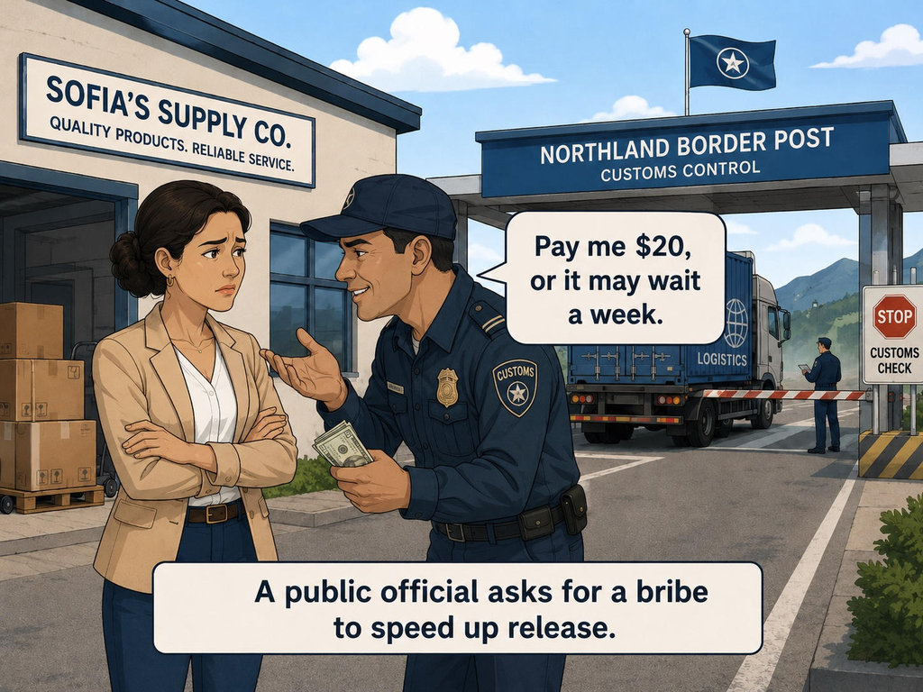

The delay at the border is genuine, and the officer really does control it. Sofia is paying to move up a queue that already existed.

## Extortion

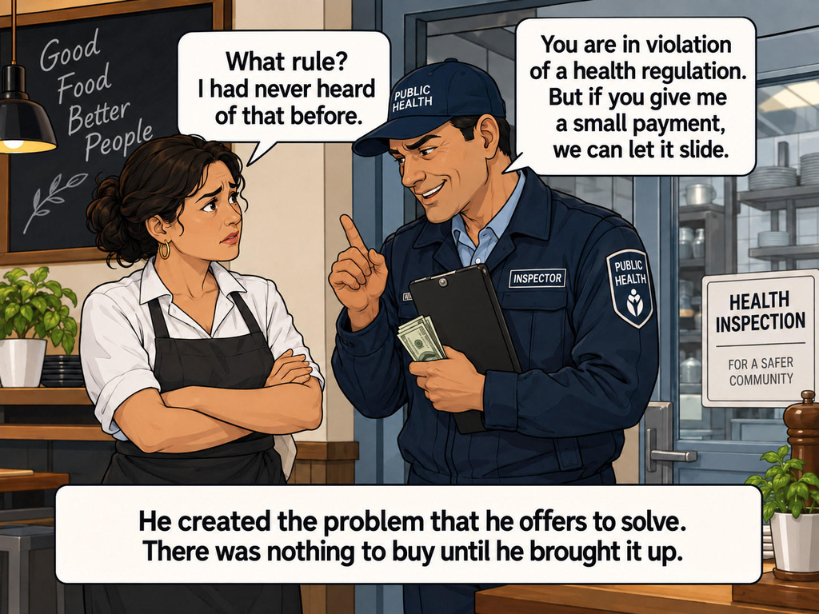

Compare this with Sofia. Her delay was real. This regulation was not.

## Embezzlement

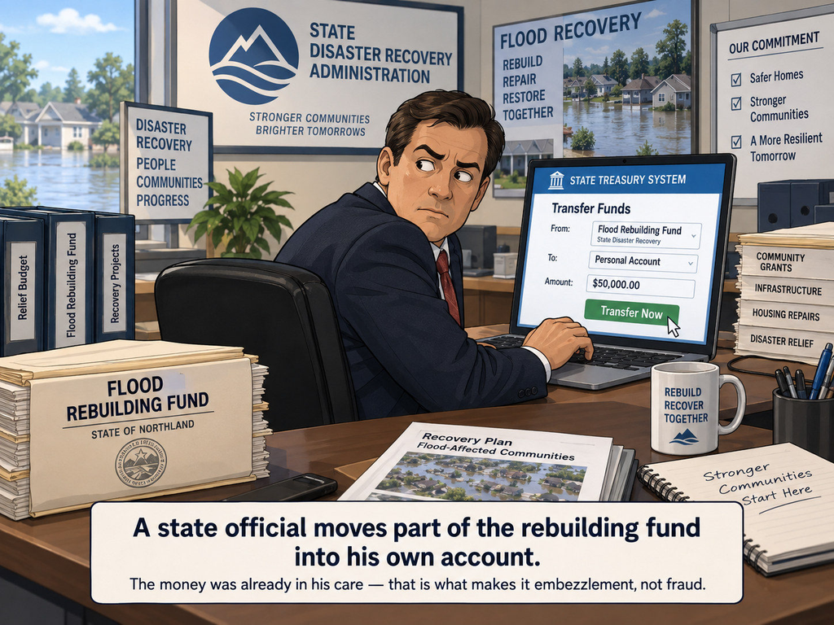

## Fraud

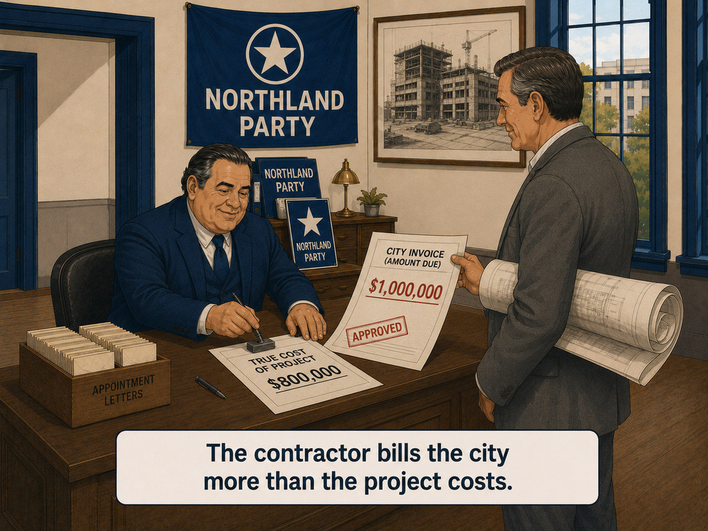

The contractor never had the city’s money. He obtained it by making the invoice say something untrue.

## Influence trafficking

[figure not shown]

Where this stops being ordinary lobbying is contested, and countries draw the line in different places.

## Clientelism

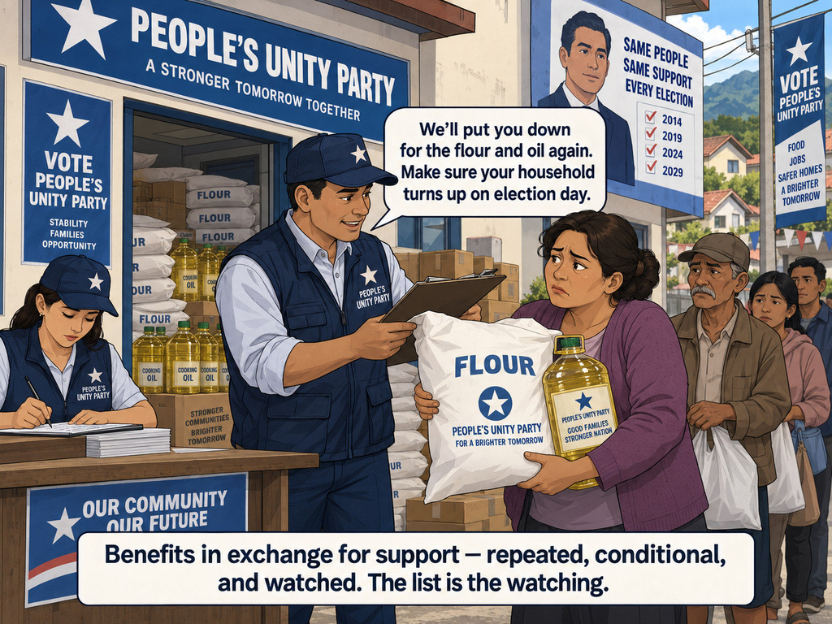

## Clientelism or vote buying

In both, a politician gives something in exchange for support. **What is handed over does not tell them apart**: the same bag of flour can be either one. What separates them is **how long the deal lasts**.

|  | Vote buying | Clientelism |
| --- | --- | --- |
| **How often** | once, at election time | again and again, election after election |
| **What is left afterwards** | nothing: paid for and done | a relationship: the benefit keeps coming as long as the support does, and someone is watching |
| **With the flour** | one bag, once, in election week | “we’ll put you down for the flour and oil *again*”, 2014, 2019, 2024, 2029, and a list of names |

That is why the previous picture is clientelism, and not because of the flour. The clues are the word *again*, the years on the banner, and the list. Ask what happens after the election: if the deal ends there, it is vote buying; if it comes back at the next one, it is clientelism.

## Patronage

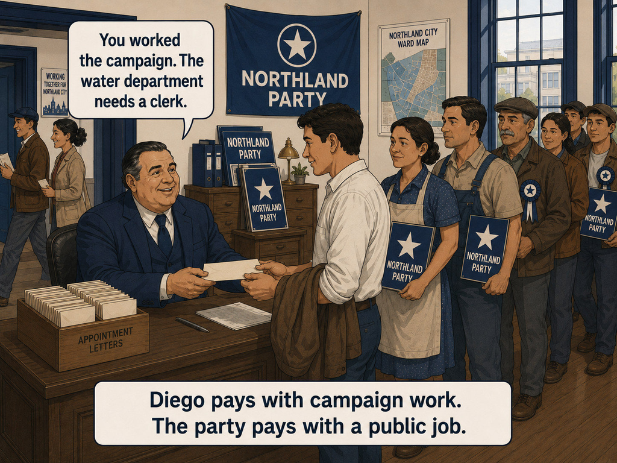

Diego is paid with a job, and he is paid for the campaigning he did rather than for his vote.

## State capture

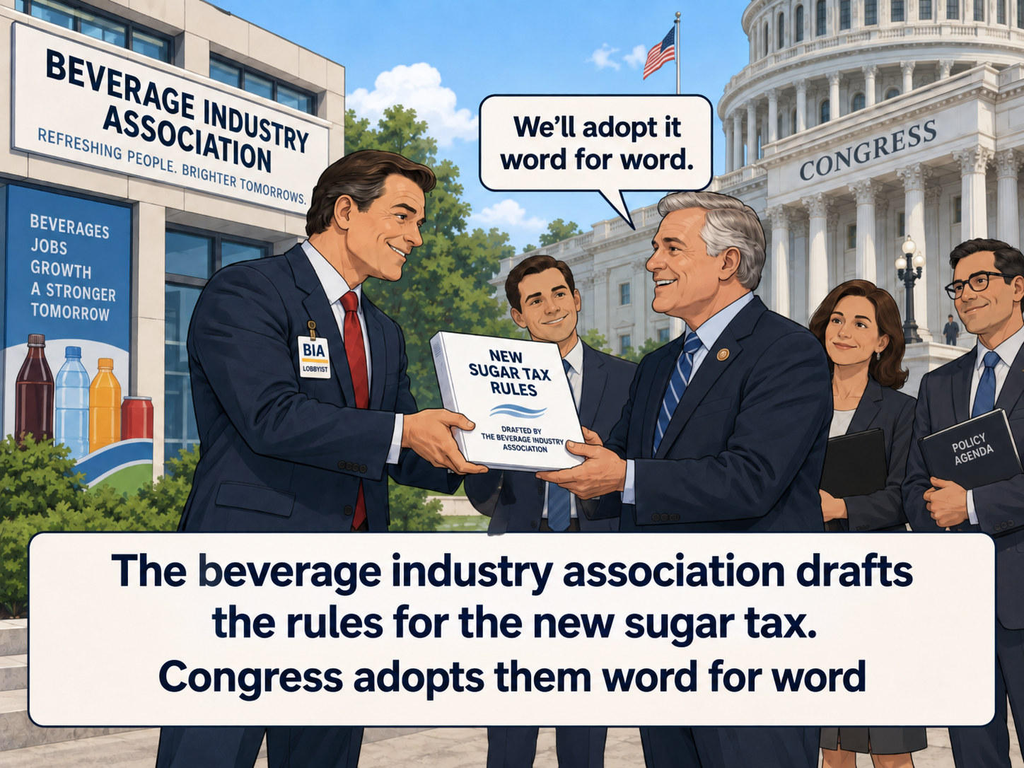

Nobody hands over money here. The industry gets what it wants when the rule is written, and once it passes, what it protects becomes legal.

## Session 2 — How to read a study

Session 2 gave you six moves. Three of them are what Thursday asks for.

- **Measurement** — what was actually counted, **and at what level**? What a study calls its subject is often not what it actually counted.
- **Comparison** — compared with *what*?
- **Rivals** — what else would produce this same pattern? Can this evidence tell them apart?

**Compared with what?** Usually one of two things: other countries at the same moment, or the same country before and after a change.

Comparing countries leaves in everything else that makes them different. Comparing before and after keeps the country itself fixed.

And when an author says he has **taken income into account**, he has removed what that one number explains, and nothing else. Whatever he never measured is still in there.

## Session 3 — Klitgaard’s three questions

$$\text{Corruption} = \text{Monopoly} + \text{Discretion} - \text{Accountability}$$

*This is a memory device rather than a calculation. It tells you where to look.*

- **Monopoly** — can the citizen go anywhere else?
- **Discretion** — who decides, and against what written rule?
- **Accountability** — who can find out, **and who can punish?**

Both halves matter. Publishing a decision lets people find out about it, but if nobody can act on what they find, publishing is not enough.

## Session 3 — Shleifer & Vishny: “theft” from whom?

The two names confuse people. The theft is **from the state**, not from Sofia.

- **Without theft** — the treasury still gets its fee.
- **With theft** — the treasury gets nothing.

That is the whole difference between the two names.

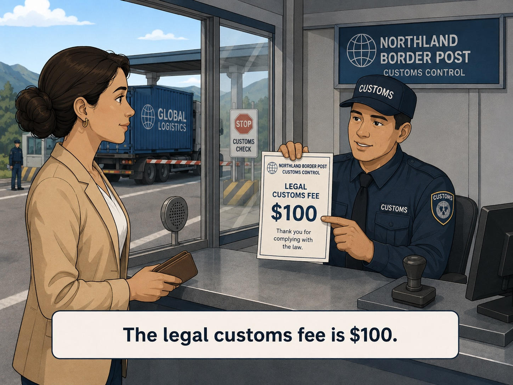

## Without theft

The legal customs fee is $100.

Sofia pays **$120**. The officer hands $100 to the state and keeps $20.

She has paid $20 more than the law asks. She is worse off than if everyone had followed the rules, so she has a reason to complain about it.

## With theft

The legal customs fee is $100.

Sofia pays **$60**. The officer records nothing and keeps all of it. The state receives **nothing**.

She has paid $40 less than the law asks. She is better off than if everyone had followed the rules.

So she will never report it. That is why this one is harder to stop.

## The two side by side

|  | Sofia pays | The state gets | The officer keeps | Would she complain? |
| --- | --- | --- | --- | --- |
| Rules followed | 100 | 100 | 0 |  |
| **Without theft** | 120 | 100 | 20 | yes, she paid more than the law asks |
| **With theft** | 60 | 0 | 60 | no, she is better off |

Ask who loses. Without theft it is Sofia, and she can be a witness. With theft it is the state, and the only two people in the room are both better off.

## Sessions 3–4 — Principal–agent

Someone hands a job to someone else, and cannot watch them do it.

- **The principal** — the supervisor. Wants permits issued properly.
- **The agent** — the clerk. Wants the twenty dollars.
- They want different things, and only one of them is at the counter.
- The clerk knows what happened there. The supervisor does not.

That gap has a name: **information asymmetry**. It is what makes the betrayal possible.

The fix looks obvious. Watch more closely, audit, raise the penalty. It works because **somebody at the top wants it fixed**.

## Session 4 — Collective action

Imagine you are the one honest clerk in the office.

- You refuse the twenty dollars. The applicant goes to the next window.
- Your colleagues keep taking it, so you earn less than all of them.
- Nothing about the office changes.

Refusing costs you something and changes nothing, so you stop refusing. What makes sense for you depends on what you expect everyone else to do.

Everyone would be better off if nobody paid. Each person alone is still better off paying.

**And there is nobody above to fix it.** The supervisor is taking a share too.

## Session 4 — Two ways to read the same office

|  | Is anyone above willing to act? | What would fix it |
| --- | --- | --- |
| **Principal–agent** | yes | better monitoring, bigger penalties |
| **Collective action** | no | nothing one person can change alone |

Almost every anticorruption reform is built for the top row. It assumes somebody in charge wants this stopped, and only needs better tools to catch the people below.

Persson, Rothstein and Teorell’s point is that in the bottom row that person does not exist.

## Session 4 — Why a bigger penalty does not help

Every clerk takes payments. Every applicant pays. The ministry **doubles the fine**.

What a clerk actually risks is not the fine on paper:

$$\text{what it costs me} = \text{the fine} \times \text{the chance anyone applies it}$$

- Doubling the fine doubles the **first** number.
- The **second** number is near zero. The people who would have to apply it are taking a share themselves.
- Twice almost nothing is still almost nothing.

## Session 4 — Corbacho’s experiment

Costa Rica. Everyone was put into one of three groups **at random**.

| Group | What they were shown |
| --- | --- |
| One third | real survey figures: people who said they had seen corruption rose 16% → 24% |
| One third | a flyer with equally bad news, about slow courts |
| One third | nothing |

The second group is the placebo. It shows that bad news in general was not what moved people.

## Session 4 — What the experiment found

**35% against 27%.** The group that saw the corruption figures was more willing to bribe a traffic officer. The placebo group did not move.

The groups were formed at random, so nothing about the people explains the gap. Only the corruption figures do.

One caution. This is what people said they would do. Nobody watched anyone pay a bribe.

## Session 5 — What corruption costs

Mauro compared **67 countries**. Where the bureaucracy is worse, there is **less investment**.

But countries differ in many ways at once, so you cannot tell which difference is doing the work.

Comparing countries cannot tell you what corruption costs. You need something that separates the cause from everything travelling with it.

## Session 5 — What a lottery buys you

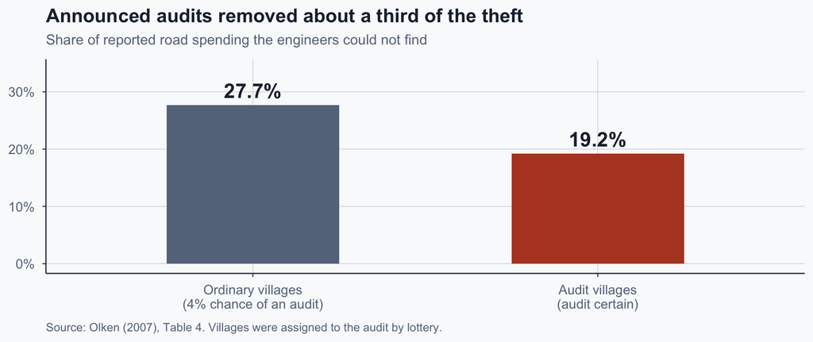

The lottery decided which villages were audited, so nothing about a village explains the gap. Only the audit does.

## Session 5 — Four ways a pattern can arise

- **The first thing causes the second.** The conclusion people usually want.
- **The second thing causes the first.** The cause and effect run the other way.
- **Something else causes both.** *You must say what it is.*
- **No real connection.** So many things were compared that one was going to match by chance.

Compare exam results against sixty things about students and something will line up: shoe size, birth month, backpack colour. The clue is how many comparisons were made.

## Session 6 — Wallis: which way is the arrow pointing?

```
%%{init: {"theme": "base", "width": 1200, "height": 400, "fontSize": 16, "themeVariables": {"fontSize": "16px", "fontFamily": "Helvetica, Arial, sans-serif", "primaryColor": "#eef2f6", "primaryTextColor": "#1e293b", "primaryBorderColor": "#334155", "lineColor": "#b44527", "edgeLabelBackground": "#f9…
flowchart LR
  A["PUBLIC OFFICE<br/>the power to decide"]
  B["ECONOMIC BENEFITS<br/>money, jobs, contracts"]
  A -- "VENAL<br/>use office for private economic gain" --> B
  B -- "SYSTEMATIC<br/>use economic privileges to sustain political power" --> A
  classDef box fill:#eef2f6,stroke:#334155,stroke-width:2px,color:#1e293b;
  class A,B box;
```

“Systematic” does **not** mean “widespread”. It describes how the corruption keeps a party in power.

This is a **different question** from Session 3’s. *With or without theft* asks what the treasury ends up with. *Venal or systematic* asks what the exchange buys. One case can be both.

## Session 6 — Which kind?

1. A customs inspector cancels an import tax for a cash payment. — **venal**
2. A mayor buys land along a subway route before the route is announced. — **venal**
3. Every firm that wins city construction work also donates to the governing party. — **systematic**
4. Only banks whose directors back the governing faction receive charters. — **systematic**

**Ask what the exchange buys.**

|  | What it buys | Kind |
| --- | --- | --- |
| 1 and 2 | a private profit | **venal** |
| 3 and 4 | a coalition that keeps the faction in power | **systematic** |

## Session 6 — A test you can apply

Jail everyone involved. Put honest people in every chair. Now what?

|  | What happens | Why |
| --- | --- | --- |
| **Venal** | it stops | it needed somebody dishonest |
| **Systematic** | it carries on | the privileges still exist, and whoever holds the office still needs a majority |

Venal corruption needs bad people. Systematic corruption needs only the arrangement.

That is why reform worked by taking away what there was to sell, rather than by replacing the people.

# Part IV — Practice

## Exercise 1 — Name the act

**One name each. One name is left over.** Choose from: bribery, extortion, embezzlement, fraud, influence trafficking, clientelism, patronage, state capture, vote buying.

1. A school principal spends the building-repair budget on a car for herself.
2. A police officer stops a driver who has done nothing wrong and says he can pay now or spend the night at the station.
3. A parent pays a university clerk to move an enrolment file to the front of the queue.
4. A caterer invoices the city for five hundred school meals a day and delivers two hundred.
5. The only technical staff the telecoms regulator has are on loan from the industry it regulates, and every draft rule comes from them.
6. A former governor takes a fee from a contractor to arrange a private meeting with the official deciding that contractor’s bid.
7. A councillor rebuilds the drainage in the streets that voted for him, after every election, and the neighbourhood committee gives him the list of who voted, street by street.
8. A new museum director replaces the whole ticketing staff with people from his party’s youth organisation.

## Exercise 1 — worked

|  | The case | Answer | Why |
| --- | --- | --- | --- |
| 1 | repair budget spent on her own car | **embezzlement** | the money was already in her care |
| 2 | pay now or spend the night in the station | **extortion** | he invented the problem he is selling relief from |
| 3 | paying to jump the enrolment queue | **bribery** | the queue is real; he is paying to get ahead of it |
| 4 | paid for 500 meals, delivers 200 | **fraud** | the invoice says something untrue |
| 5 | the industry supplies the regulator’s staff and writes its drafts | **state capture** | the rules themselves are written by the industry |
| 6 | a fee to reach the official deciding the bid | **influence trafficking** | what is sold is access, not the decision |
| 7 | drainage for the streets that voted, after every election | **clientelism** | benefits for support, given again and again |
| 8 | ticketing staff replaced by the party youth organisation | **patronage** | public jobs handed out for political loyalty |

Items 2 and 3 are the ones to get right. Ask who made the problem. Item 3’s queue was there before anyone spoke; item 2’s offence never existed at all.

**Left over: vote buying** — a single purchase at election time. Item 7 happens after every election, and it is that repetition that makes it clientelism.

## Exercise 2 — Name the concept

**One phrase each. One label is left over.** Choose from: corruption with theft, corruption without theft, systematic corruption, venal corruption, state capture. Items 1 and 2 are about what the treasury ends up with. Items 3 and 4 are about which way the influence runs.

1. A market inspector tells a trader the fee for her stall is 250 pesos rather than the legal 500, writes no receipt, and keeps all of it.
2. A hospital records the official consultation fee and pays it into the state’s account, and the doctor asks the same patient for an extra payment to be seen this week.
3. A city engineer approves his cousin’s building plans in exchange for one of the flats.
4. A governor gives the only alcohol-distribution licences to the families who fund his campaign, and that funding is what keeps him in office.

## Exercise 2 — worked

|  | The case | Answer | Why |
| --- | --- | --- | --- |
| 1 | 250 pesos instead of the legal 500, no receipt, he keeps it | **with theft** | the treasury gets nothing, and the trader pays less than she legally owes |
| 2 | official fee banked, extra payment to be seen sooner | **without theft** | the treasury still gets its fee; the payment sits on top |
| 3 | plans approved in exchange for a flat | **venal** | he uses the office to get something for himself: office → money |
| 4 | licences only to the families who fund the campaign | **systematic** | the licences are what keeps him in office |

Jail everyone in case 4 and the arrangement still works. Do the same in case 3 and it stops.

**Left over: state capture** — that is about who writes the rules, not about which way a single exchange runs.

## Exercise 3 — What would you change first?

**A label and one sentence. One label is left over.** 1 mark for the label, 2 for the sentence, which must say who cannot do what. Choose from: reduce monopoly, reduce discretion, raise accountability, replace the official, or none of these — it is a collective-action problem.

1. Only one laboratory in the country can certify that a food product is safe to export.
2. A housing officer decides who gets a subsidised flat. There is no written list of criteria, and the wait runs from two months to six years.
3. Land registry decisions are recorded on paper in the office that made them, and no other body can review them.
4. Every driving examiner takes a payment, every candidate pays, and both say so openly — and the examiners’ supervisors take a share of every payment. The ministry announces a complaints hotline, staffed by those supervisors.

## Exercise 3 — worked

|  | The case | Answer | The sentence that earns the two marks |
| --- | --- | --- | --- |
| 1 | one laboratory, no alternative | **reduce monopoly** | the exporter cannot go anywhere else, so she cannot refuse |
| 2 | no written criteria, two months or six years | **reduce discretion** | nothing says how he must decide, so the difference between two months and six years is his to sell |
| 3 | paper records, no outside review | **raise accountability** | nobody outside can find out, and nobody outside can act |
| 4 | everyone pays, everyone takes, a hotline staffed by the supervisors | **none of these — collective action** | the hotline reports to the supervisors, who are taking a share themselves, so there is nobody above willing to act |

The label is worth one mark. The sentence in the right-hand column is worth the other two.

**Left over: replace the official** — Session 4 showed why. Fire the worst two and the replacements learn the price within a week.

## Exercise 4 — Explain the pattern

**A phrase and a few words.** Choose from: the first thing causes the second; the second thing causes the first; something else causes both; no real connection; too few cases to tell. One is left over. Where an item compares two things, “the first thing” is the one named first.

1. “Ticket inspectors were put on half a city’s bus routes, chosen by lottery. Fare evasion fell on the routes that were chosen.”
2. “A newspaper tested sixty possible explanations for which schools score best. The closest match was how far the school is from the sea.”
3. “The hospitals with the most safety inspectors have the most accidents. The inspectors were sent in after a series of accidents at those hospitals.”
4. “Children who go to private tutoring also eat better at home. So tutoring improves a child’s diet.”

## Exercise 4 — worked

|  | The case | Answer | Why |
| --- | --- | --- | --- |
| 1 | bus routes chosen by lottery, evasion fell | **the first thing causes the second** | the lottery makes the routes alike beforehand, and only one comparison was made |
| 2 | sixty explanations tested, distance from the sea matched best | **no real connection** | sixty tries, so one was going to fit |
| 3 | inspectors sent in after a series of accidents | **the second thing causes the first** | the accidents came first, and are why the inspectors are there |
| 4 | tutoring and eating better at home | **something else causes both** | family income buys both |

In item 4 you have to say what the something else is. Answering “something else causes both” and stopping earns 1 mark of the 3. Naming “family income” earns the other two.

**Left over: too few cases to tell** — half a city’s bus routes, sixty explanations, a whole hospital system, a whole cohort of children. None of these is short of cases.

## Exercise 5 — Read the study

A study reports that across 90 countries, those with more newspapers per person score better on a corruption index. The corruption figure is an index built from surveys of international business executives, one score per country, all collected in the same year. The author has already taken each country’s income into account, so “they are richer” on its own earns nothing. What still counts is saying what that control does **not** remove. He concludes that a free press reduces corruption.

**Two or three sentences for each answer.**

**(a)** What was actually measured, and who did the measuring? Name one problem and say why it matters.

**(b)** Compared with what? Say what each country is compared against, and name one rival explanation that comparison cannot rule out.

## Exercise 5 — what a full-mark answer does

**(a)** It measures **perceived** corruption. What was collected is the opinions of international executives, one score per country.

*The problem:* executives may be rating a country’s wealth, its press freedom, or its reputation rather than its conduct. If they partly read “free press” as “clean”, the finding is built into the way the score was made.

**(b)** Each country is compared with **other countries**, never with its own past. There is no before-and-after inside any country.

*The rival:* **how strong the state is** — how old the administration is, how well staffed, how closely it follows its own rules. Strong states print more newspapers *and* run cleaner offices. Allowing for income only removes the part of that history that one income number captures.

Two or three sentences for each answer.

## Exercise 6 — Match the reading

One letter each. One option is left over.

1. Klitgaard, *Controlling Corruption*
2. Shleifer and Vishny, “Corruption”
3. Persson, Rothstein and Teorell, “Why Anticorruption Reforms Fail”
4. Wallis, “The Concept of Systematic Corruption in American History”
5. Mauro, “Corruption and Growth”
1. why the person who paid may want to keep it secret
2. how economic favours once kept a governing group in power
3. why a tougher law changes nothing when nobody will apply it
4. a checklist for deciding which offices are most at risk
5. whether countries with worse bureaucracies also get less investment
6. why paying officials better salaries does not by itself stop them

**1** a checklist for offices at risk · **2** why the payer keeps quiet · **3** why a tougher law changes nothing · **4** how economic favours kept a group in power · **5** bureaucracy and investment.

On the paper the options are worded differently and carry different letters. Match the **idea**, not the letter.